# Annual Report Data Analysis - Question 3.03 and 3.04

Tristan Burgess and Cristin Young

2026-03-18

# 3. Did EBP/CDEP services impact clinical and functional outcomes for clients who participated?

**Inclusion criteria:** 1. must have initial time point data (i.e., be enrolled in an intervention), 2. must have a valid assessment collected at both intake and discharge time points, and 3. limited to tools with a clinical cut-off.

**Scoring:** An **increase** in score indicates a positive outcome. There are no benchmarks or clinical cutoffs established for NOMS scoring — if the follow-up assessment score is higher than the initial score, a positive outcome is indicated.

**Assumptions:** Filtered out dates before 2024-01-01 and after the date the code was run. Filtered data that’s >3 days from initial assessment and paired to the LAST follow-up. Filtered positive outcomes that had NAs before computing %.

## 3.03 To what extent did parents/caregivers report improved mental health for themselves and their child after receiving the intervention?

Range: 1–5; Sum = Q1.

Use the `pairs_primary_long_child` data frame to compute scores. The following had a positive outcome:

```
 positive_outcome   n percent
         worsened  68     10%
        no_change 257     38%
         improved 359     52%
```

Plot it.

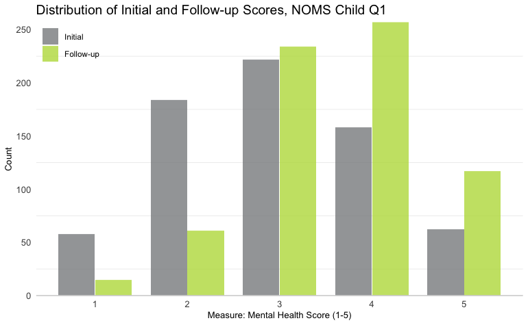

Ridgeline plot

| score_type | mean_score | median_score | sd_score | n |
| --- | --- | --- | --- | --- |
| Initial | 2.973684 | 3 | 1.0967317 | 684 |
| Follow-up | 3.584795 | 4 | 0.9466608 | 684 |

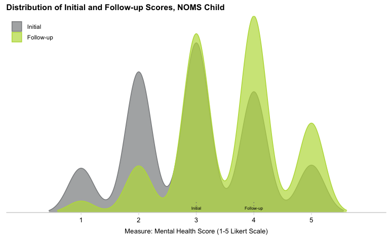

Dot and arrow plot

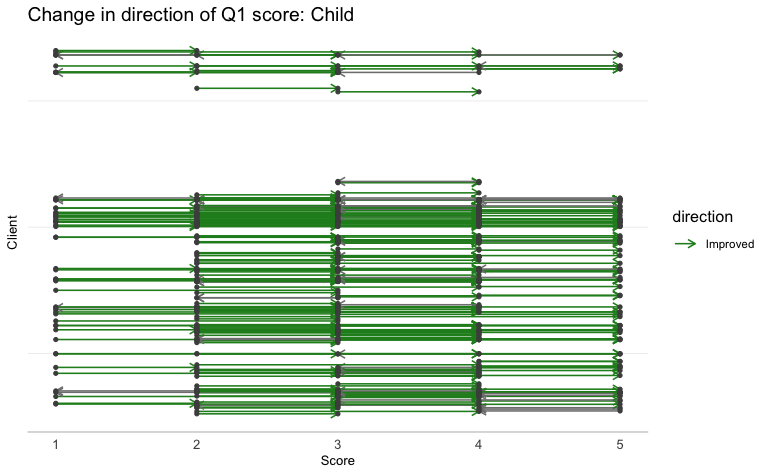

#### Summary stats

The percent of those who selected ratings of 4 or higher (excellent or very good) across Q1 at initial and discharge time points were:

[output not shown]

## 3.04 To what extent did the youth report improved mental health after receiving the intervention?

Range: 1–5; Sum = Q1.

Use the `pairs_primary_long_self` data frame to compute scores. The following had a positive outcome:

```
 positive_outcome   n percent
         worsened 868     41%
        no_change 483     23%
         improved 789     37%
```

Plot it.

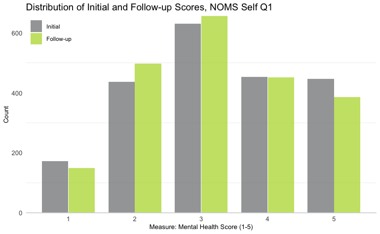

Ridgeline plot

| score_type | mean_score | median_score | sd_score | n |
| --- | --- | --- | --- | --- |
| Initial | 3.264486 | 3 | 1.226233 | 2140 |
| Follow-up | 3.198598 | 3 | 1.185189 | 2140 |

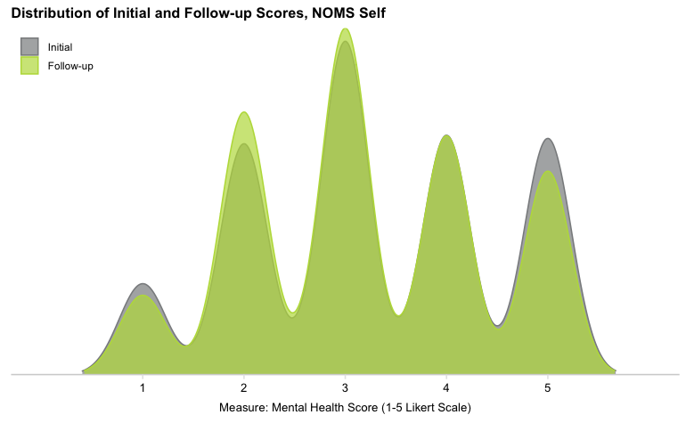

Dot and arrow plot

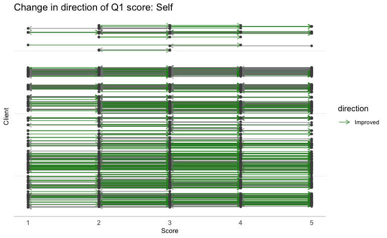

#### Summary stats

The percent of those who selected ratings of 4 or higher (excellent or very good) across Q1 at initial and discharge time points were:

| initial_4_5 | followup_4_5 |
| --- | --- |
| 42.44 | 39.09 |

### Summary stats overall

[figure not shown]